# ==========================

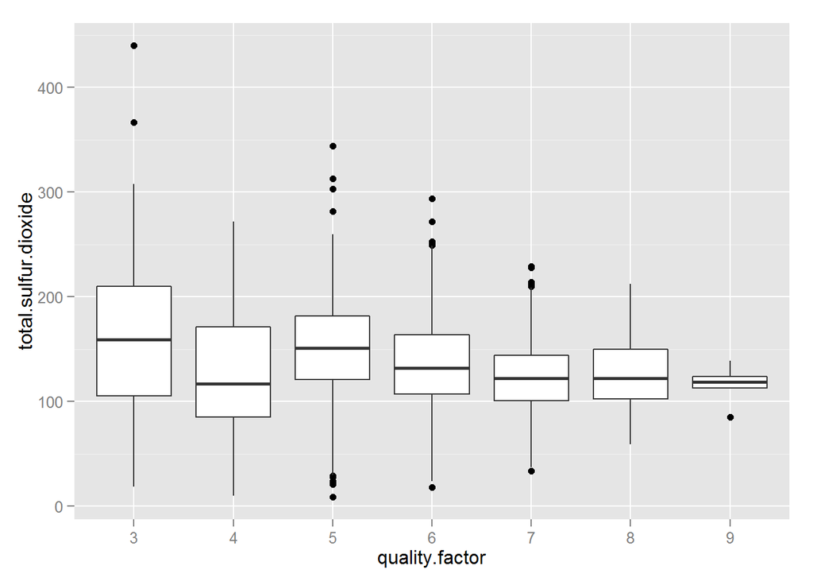

Semilar to chlorides, we noted a slight decline in total sulfur dioxid when the quality increase.The dispersion of data points seems to become contract when quality increase.

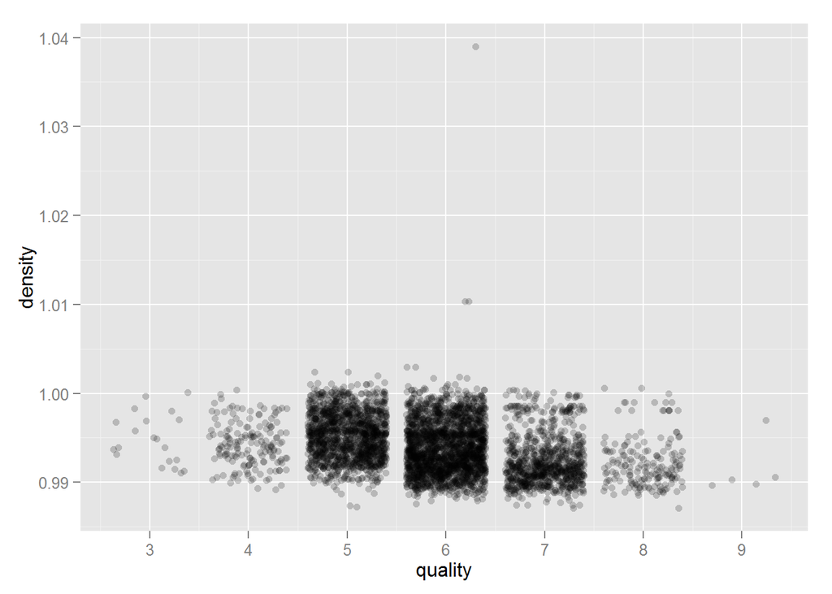

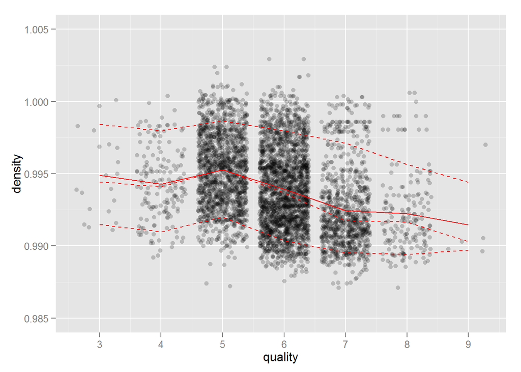

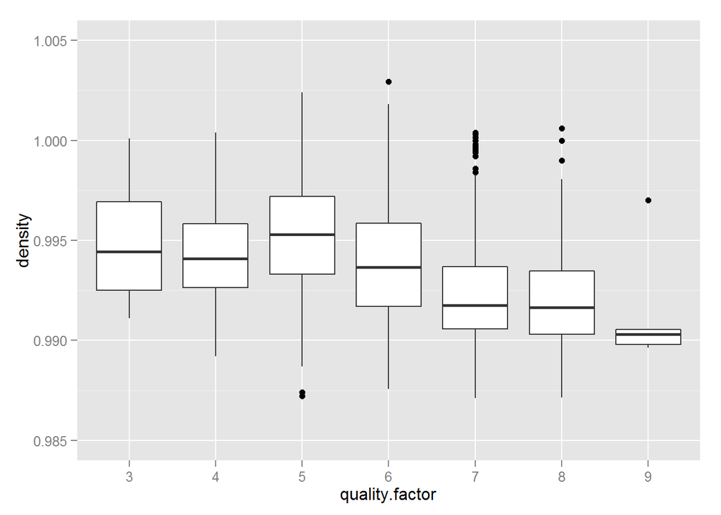

It seems obvious that lower the density of the white wine, better its quality.

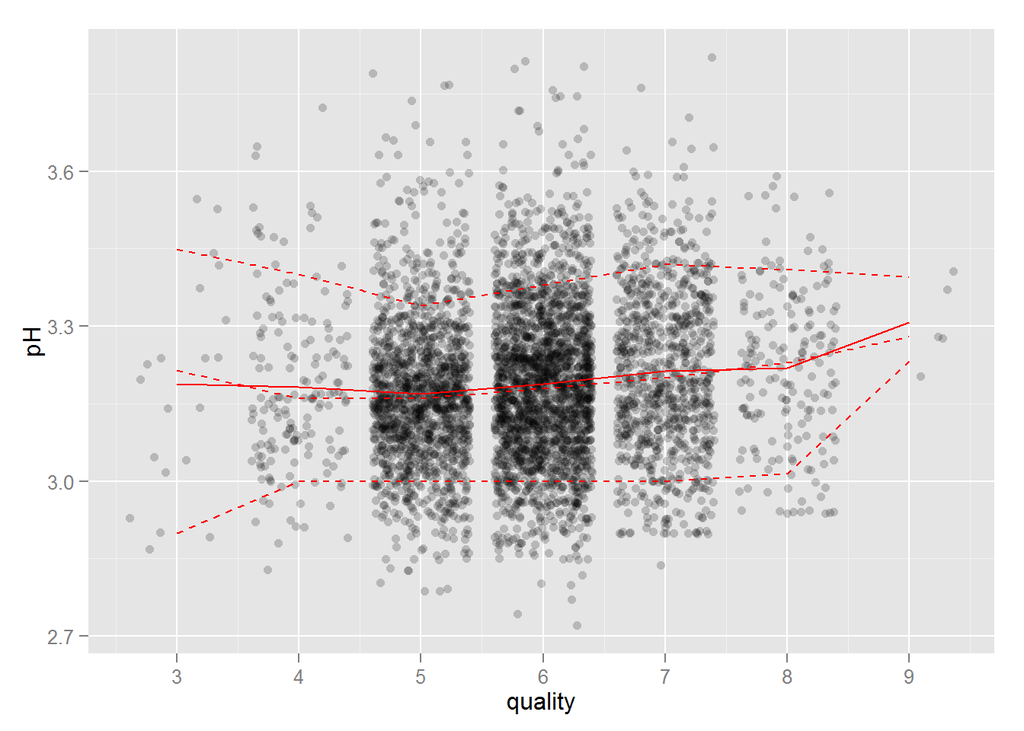

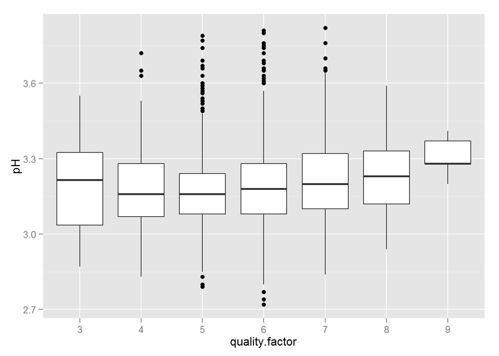

We noted that the quality of wine becomes better when the PH value increase. There are pretty many outliers for quality 5, 6 and 7.

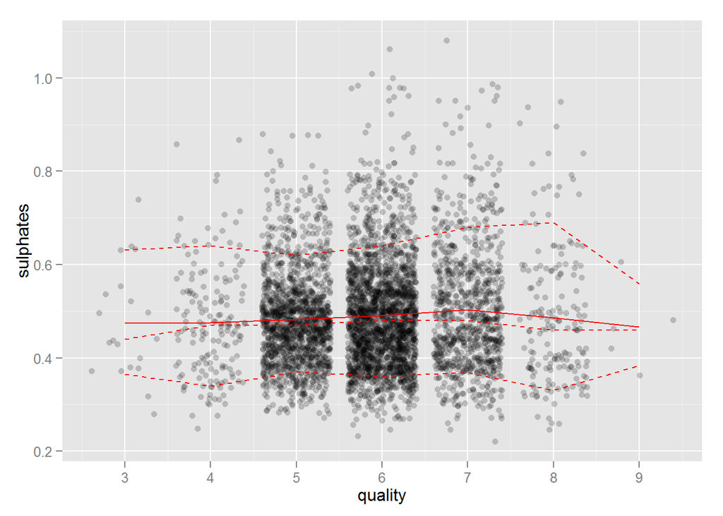

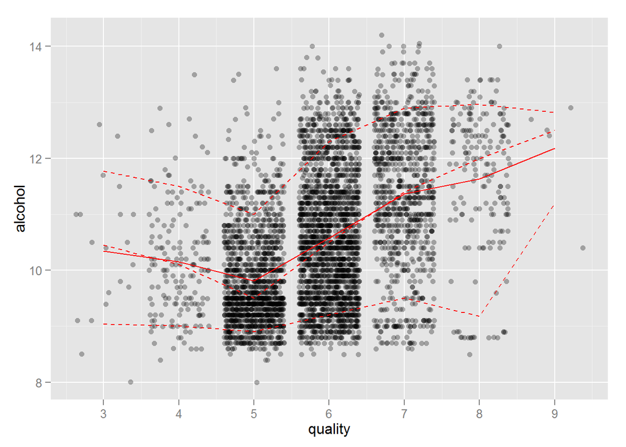

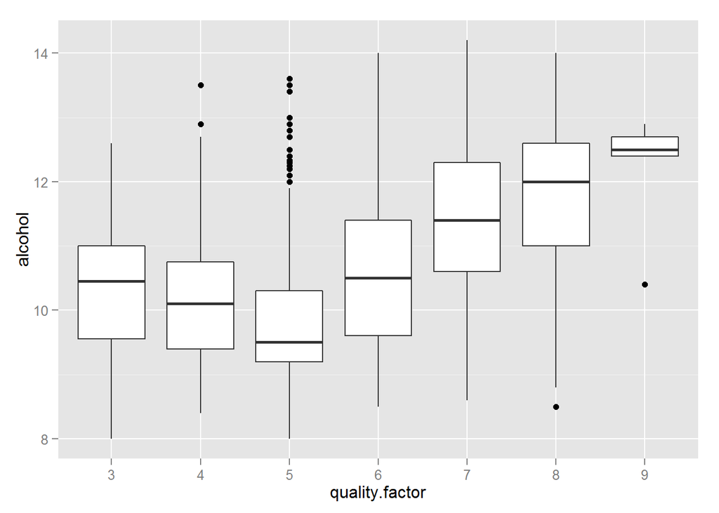

```
## wine$quality: 3
##    Min. 1st Qu.  Median    Mean 3rd Qu.    Max.
##    8.00    9.55   10.45   10.34   11.00   12.60
## --------------------------------------------------------
## wine$quality: 4
##    Min. 1st Qu.  Median    Mean 3rd Qu.    Max.
##    8.40    9.40   10.10   10.15   10.75   13.50
## --------------------------------------------------------
## wine$quality: 5
##    Min. 1st Qu.  Median    Mean 3rd Qu.    Max.
##   8.000   9.200   9.500   9.809  10.300  13.600
## --------------------------------------------------------
## wine$quality: 6
##    Min. 1st Qu.  Median    Mean 3rd Qu.    Max.
##    8.50    9.60   10.50   10.58   11.40   14.00
## --------------------------------------------------------
## wine$quality: 7
##    Min. 1st Qu.  Median    Mean 3rd Qu.    Max.
##    8.60   10.60   11.40   11.37   12.30   14.20
## --------------------------------------------------------
## wine$quality: 8
##    Min. 1st Qu.  Median    Mean 3rd Qu.    Max.
##    8.50   11.00   12.00   11.64   12.60   14.00
## --------------------------------------------------------
## wine$quality: 9
##    Min. 1st Qu.  Median    Mean 3rd Qu.    Max.
##   10.40   12.40   12.50   12.18   12.70   12.90
```

For good wines (quality >= 5), there is an obvious trend that the quality of wine increase when the level of alcohol increase, which is consitent with the common sense (maybe not correct) that the longer the wine is made and stored, better its quality and taste.

Now before to explore the relationship between other features, I’d like to have a quick view of the correlation of different variables. Fot this, I used the function pairs.panels.

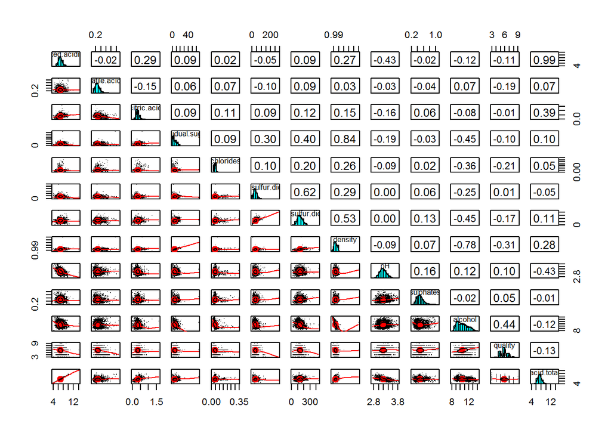

We can see among these non-main features, residual.sugar has a very strong relationship with the density. There is also a strong negative relationship between denstiy and alcohol. Free.sulfur.dioxide correlates much with total.sulfur.dioxide. That’s what we expect as the two variables are in fact of the same nature type. We also find the acid.total has certain correlation with PH which is normal as PH is a standard test to evaluate how acidic or basic the liquide is. Some other medium correlation pairs can be found between total.sulfur.dioxide and denstiy, residual.sugar and alcohol, total.sulfur.dioxide and alcohol.

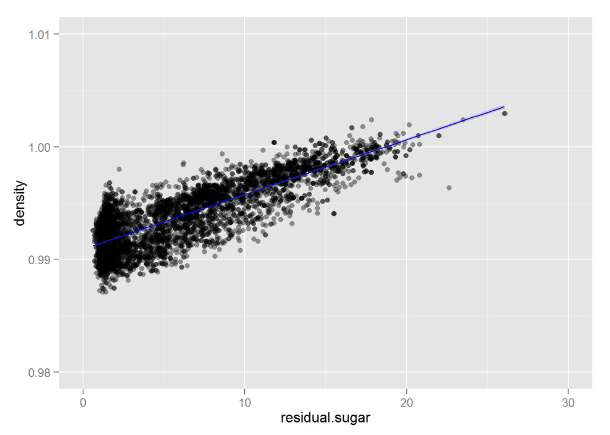

After excluding the outliers whose residual sugar value is larger than 30, we observed a quite well linear model between residual.sugar and density.

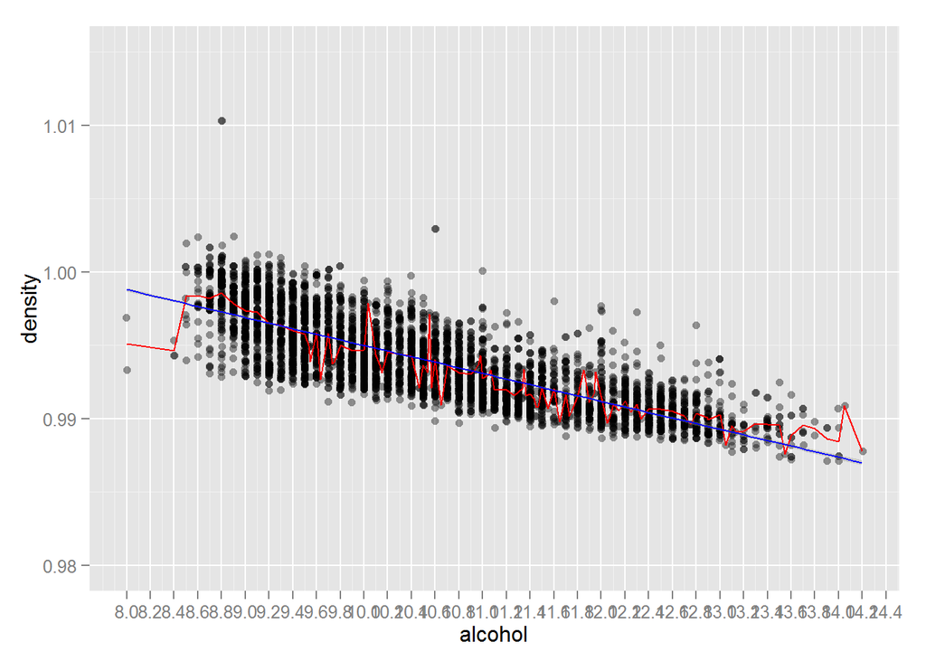

The plot showed a cluster of vertical lines which means that the alcohol values are ofen regular on basis of 0.1. The mean of density over the alcohol has much variation, so I added a linear smooth. However, the blue line doesn’t seem to predict well the denstity value on the right part of the plot where the alcohol level is high. So I decided to try a second order linear model.

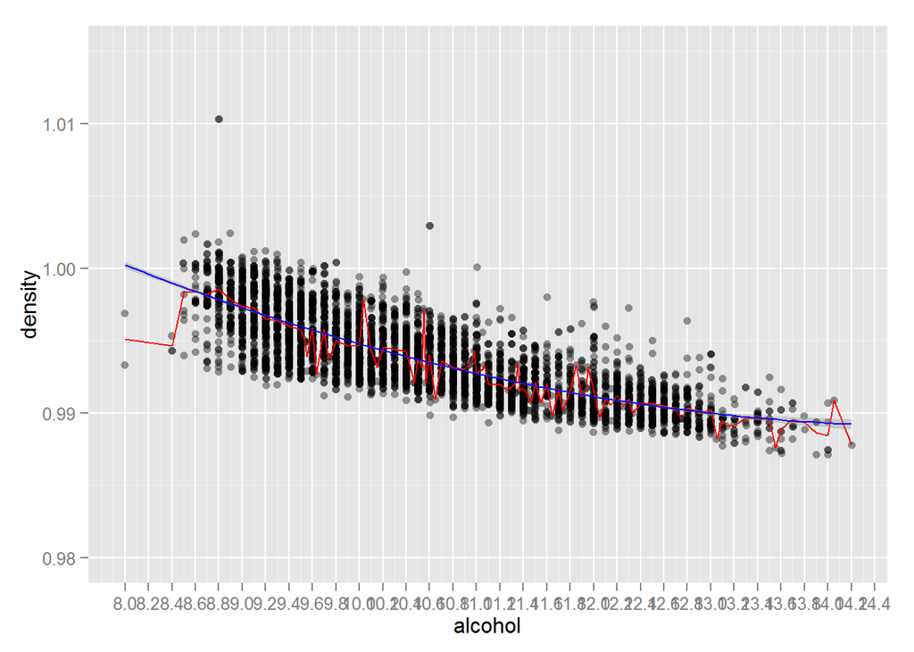

```
##
## Call:
## lm(formula = density ~ alcohol + I(alcohol^2), data = wine)
##
## Residuals:
##       Min        1Q    Median        3Q       Max
## -0.006877 -0.001143 -0.000194  0.001141  0.047383
##
## Coefficients:
##                Estimate Std. Error t value Pr(>|t|)
## (Intercept)   1.040e+00  1.954e-03  532.02   <2e-16 ***
## alcohol      -6.698e-03  3.646e-04  -18.37   <2e-16 ***
## I(alcohol^2)  2.220e-04  1.683e-05   13.20   <2e-16 ***
## ---
## Signif. codes:  0 '***' 0.001 '**' 0.01 '*' 0.05 '.' 0.1 ' ' 1
##
## Residual standard error: 0.001839 on 4895 degrees of freedom
## Multiple R-squared:  0.6221, Adjusted R-squared:  0.6219
## F-statistic:  4028 on 2 and 4895 DF,  p-value: < 2.2e-16
```

Now the blue line seems to track well the relatoinship between density and alcohol. The R-square value showed the alcohol could explain 62% of the variance in denstity. As the resigual surgar is also strongly correlated with density, I decided to build a model to predict the denstiy of the wine based on residual.sugar and alcohol.

```
##
## Call:
## lm(formula = density ~ residual.sugar + alcohol + I(alcohol^2),
##     data = wine)
##
## Residuals:
##        Min         1Q     Median         3Q        Max
## -0.0020934 -0.0005749 -0.0001250  0.0004479  0.0245036
##
## Coefficients:
##                  Estimate Std. Error t value Pr(>|t|)
## (Intercept)     9.962e-01  1.026e-03 970.707   <2e-16 ***
## residual.sugar  3.674e-04  2.979e-06 123.340   <2e-16 ***
## alcohol         3.319e-04  1.887e-04   1.759   0.0787 .
## I(alcohol^2)   -7.146e-05  8.637e-06  -8.273   <2e-16 ***
## ---
## Signif. codes:  0 '***' 0.001 '**' 0.01 '*' 0.05 '.' 0.1 ' ' 1
##
## Residual standard error: 0.0009074 on 4894 degrees of freedom
## Multiple R-squared:  0.908,  Adjusted R-squared:  0.908
## F-statistic: 1.61e+04 on 3 and 4894 DF,  p-value: < 2.2e-16
```

The R-square value is 0.908 showing it’s a pretty good model to predict the density of a wine.

Now I want to look into the detail correlation values of certain variables.

```
##
##  Pearson's product-moment correlation
##
## data:  alcohol and quality
## t = 33.8585, df = 4896, p-value < 2.2e-16
## alternative hypothesis: true correlation is not equal to 0
## 95 percent confidence interval:
##  0.4126015 0.4579941
## sample estimates:
##       cor
## 0.4355747
```

```
##
##  Pearson's product-moment correlation
##
## data:  residual.sugar and density
## t = 107.8749, df = 4896, p-value < 2.2e-16
## alternative hypothesis: true correlation is not equal to 0
## 95 percent confidence interval:
##  0.8304732 0.8470698
## sample estimates:
##       cor
## 0.8389665
```

```
##
##  Pearson's product-moment correlation
##
## data:  density and total.sulfur.dioxide
## t = 43.7186, df = 4896, p-value < 2.2e-16
## alternative hypothesis: true correlation is not equal to 0
## 95 percent confidence interval:
##  0.5094349 0.5497297
## sample estimates:
##       cor
## 0.5298813
```

```
##
##  Pearson's product-moment correlation
##
## data:  alcohol and density
## t = -87.2549, df = 4896, p-value < 2.2e-16
## alternative hypothesis: true correlation is not equal to 0
## 95 percent confidence interval:
##  -0.7908646 -0.7689315
## sample estimates:
##        cor
## -0.7801376
```

```
##
##  Pearson's product-moment correlation
##
## data:  alcohol and total.sulfur.dioxide
## t = -35.1501, df = 4896, p-value < 2.2e-16
## alternative hypothesis: true correlation is not equal to 0
## 95 percent confidence interval:
##  -0.4709775 -0.4262443
## sample estimates:
##        cor
## -0.4488921
```

```
##
##  Pearson's product-moment correlation
##
## data:  residual.sugar and alcohol
## t = -35.3209, df = 4896, p-value < 2.2e-16
## alternative hypothesis: true correlation is not equal to 0
## 95 percent confidence interval:
##  -0.4726723 -0.4280267
## sample estimates:
##        cor
## -0.4506312
```

# Bivariate Analysis

### Talk about some of the relationships you observed in this part of the investigation. How did the feature(s) of interest vary with other features in the dataset?

By making plots of different variables against quality, I found volatile.acidity, residual.sugar, chlorides, total.sulfur.dioxide, denstiy, PH and alcohol could have some influence on the quality of wine.

The most evident influence comes from the level of alcohol. There are many horizontal bands where a lot of wines take on the same alcohol value for different quality. We noted that for good wines (quality >=5), there is a strong positive relationship between alcohol and quality. Better the quality of the white wine, higher the level of average alcohol content. The PH value tends to also positively contribute to the quality of wine. Better wines seems to have higher mean PH values. But this tend is very slight.

While opposite to the alcohol, the chlorides has a negative relationship with quality. When the mean chlorides content increase, the quality seems to degrade. Similarly, residual.sugar, total.sulfur.dioxide, denstiy, and volatile.acidity all seem to have a negative influence on the quality of a wine. While the impact of certain variables (volatile.acidity and total.sulfur.dioxide) tend to be very small according to the plots.

### Did you observe any interesting relationships between the other features (not the main feature(s) of interest)?

I mainly studied the relationship between density and residual.sugar, as well as the one between density and alcohol.

Residual.sugar is postitively correlated with density while alcohol is negatively correlated with density.

The relationship between residual.sugar and density can be well expressed by a linear model (density ~ residual.sugar). While I found for alcohol and density, we need a second order (density ~ alcohol + I(alcohol^2)) to explain well the variation of density. If we include both residual.sugar and alcohol, we could obtain a pretty good R-square value of 0.908 to predict the density of the wine. And the model I got was: density = 9.962e-01 + 3.674e-04 * residual.sugar + 3.319e-04 * alcohol -7.146e-05 * I(alcohol^2)).

### What was the strongest relationship you found?

The most strongest relatoinship I found was between the residual.sugar and density. The correlation was about 0.839, and the plot showed a pretty good linear model fitness.

# Multivariate Plots Section

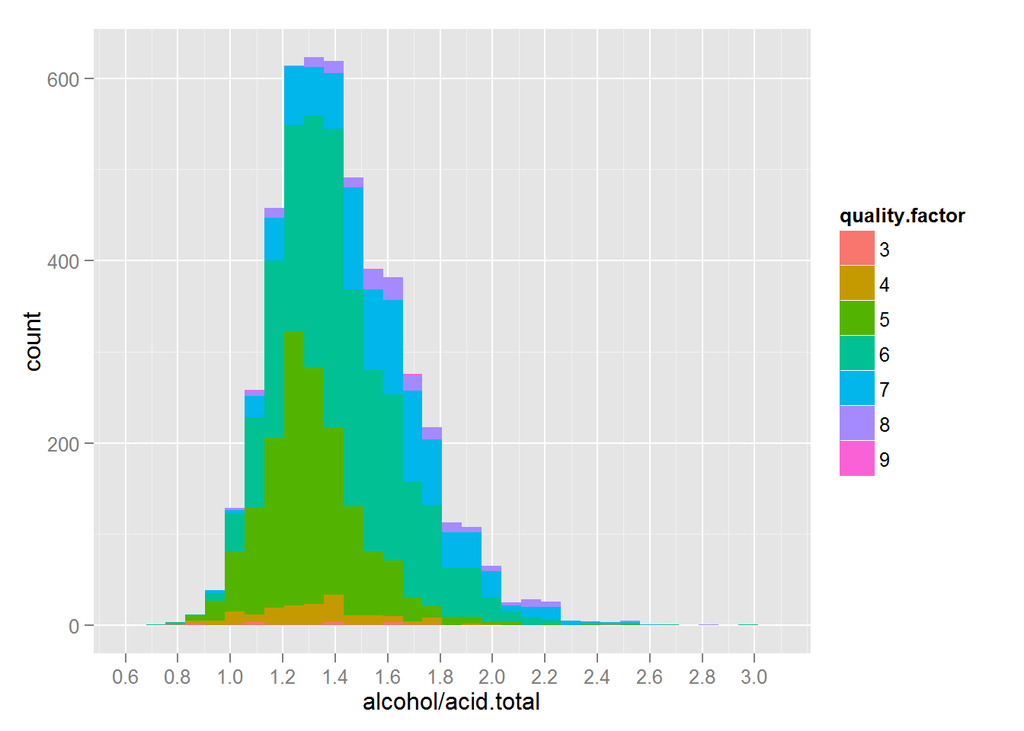

alcohol/acid.total does’t correspond to something meaningful, I just to see if this combinasion can give some pattern. According to the plot above, it seems that the better quality wines have higher mean value of alcohol/acid.total.

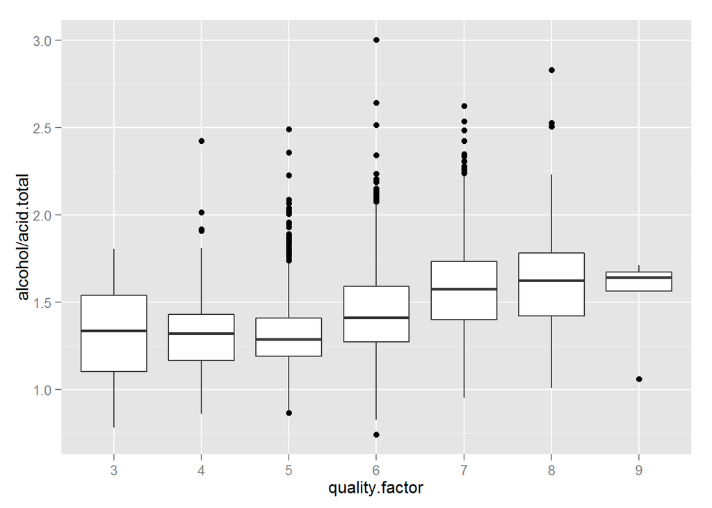

The box plot confirm this tend that alcohol/acid.total increase when the quality of wine increase. There are a lot outliers as well.

```
##
##  Pearson's product-moment correlation
##
## data:  alcohol/acid.total and quality
## t = 27.929, df = 4896, p-value < 2.2e-16
## alternative hypothesis: true correlation is not equal to 0
## 95 percent confidence interval:
##  0.3462979 0.3946184
## sample estimates:
##      cor
## 0.370709
```

We noted a correlation of 0.37 betwwen alcohol/acid.total and quality which is higher than most correlation values of a single variable (except alcohol it-self) against quality. Maybe I can include alcohol/acid.total in my model to predict a wine’s quality. However, this correlation may be stregthened by the variable alcohol as alcohol is strongly correlated with quality.

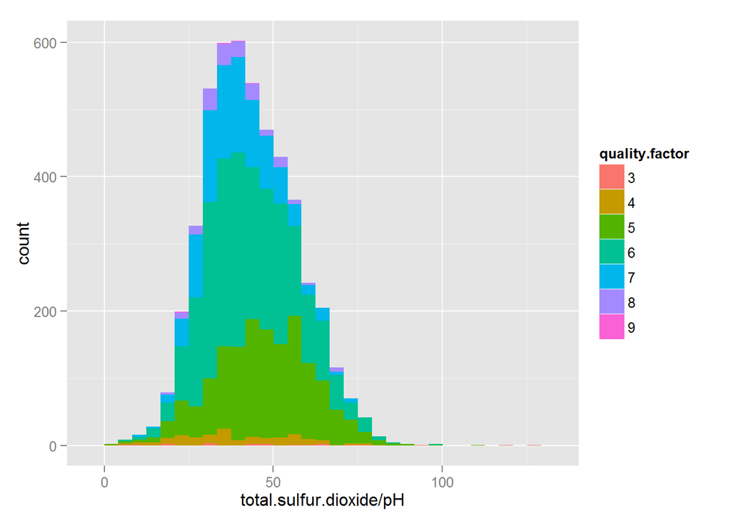

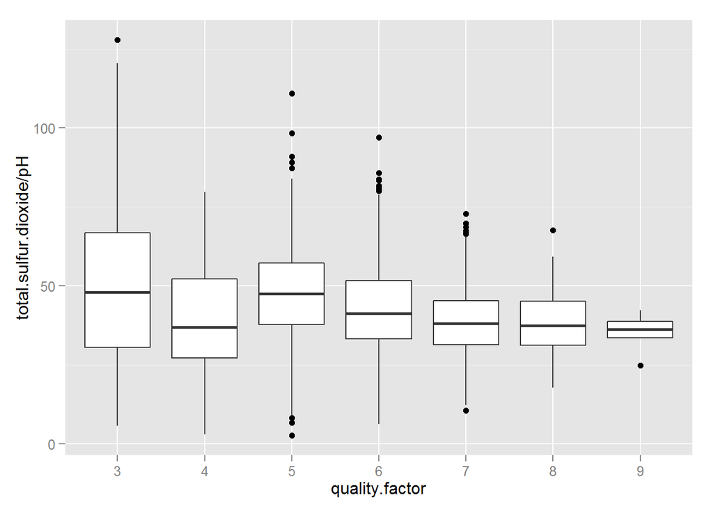

```
##
##  Pearson's product-moment correlation
##
## data:  total.sulfur.dioxide/pH and quality
## t = -13.175, df = 4896, p-value < 2.2e-16
## alternative hypothesis: true correlation is not equal to 0
## 95 percent confidence interval:
##  -0.2119480 -0.1578515
## sample estimates:
##      cor
## -0.18504
```

Opposite to the relation of alcohol/acid.total to quality, we observed that the mean of total.sulfur.dioxide/pH seems to be slightly declined when the quality of wine increase. There was an odd decrease of total.sulfur.dioxide/pH for wines of quality 4. Another remark was that the variation of total.sulfur.dioxide/pH tends to be reduced when the quality of wine becomes better.

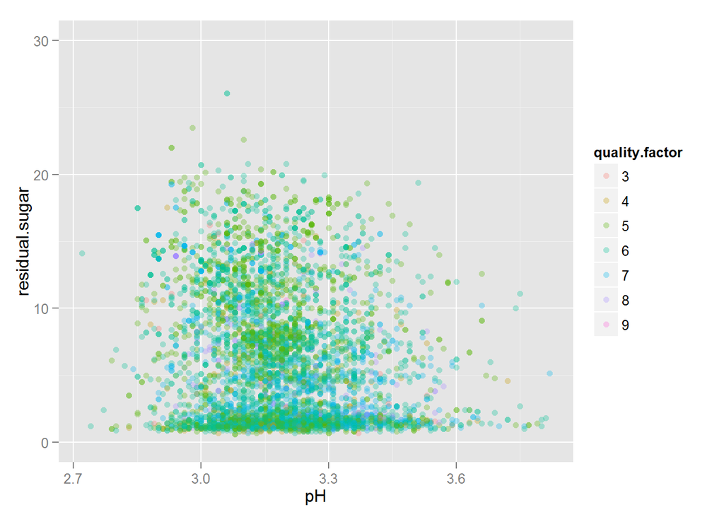

Data points of better quality wines seem to be more dispersed than those of lower qualities. No other things stand out in the plot.

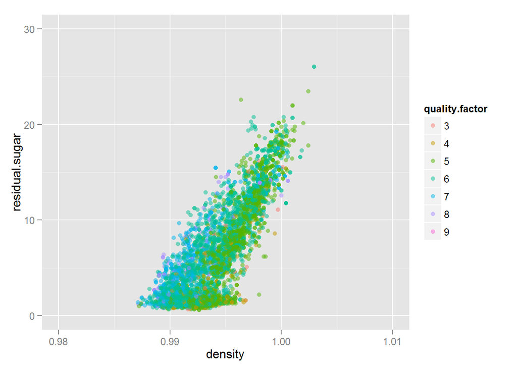

The plot showed an evident linear model for residual.sugar against density, which was consist with my previous analyse that residual.sugar was highly correlated with density. Better quality wines seem to have smaller slope of residual.sugar againt density. Now I was interested by how the points would be located for alcohol(another variable which is also strongly correlated with density) against density.

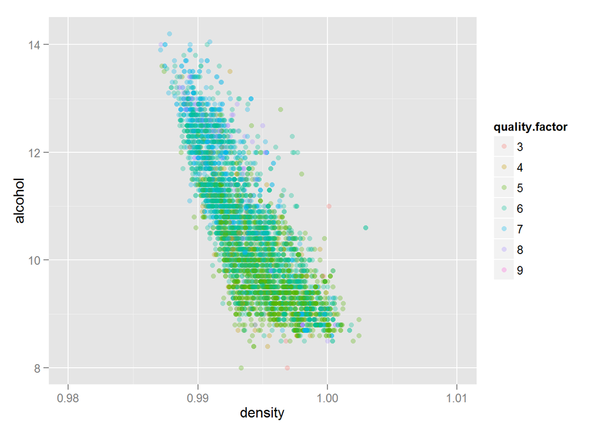

We could see that higher quality points tend to appear more on the upper part of the plot, and lower quality wines formed a cluster on the lower part of the figure.

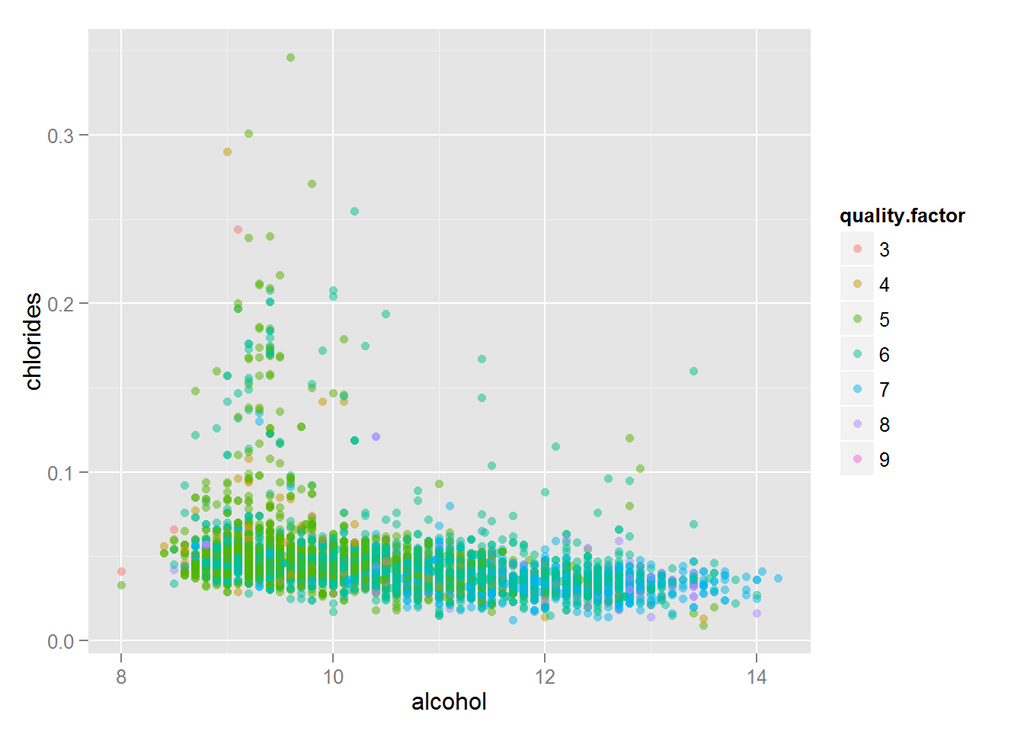

Semilar to previous plot, higher quality wines appeared more on the right part of the plot where the alcohol level was higher. As explored in bivariate section, better quality wines have higher alcohol content. This plot confirmed on another degree that alcohol has much more influence on the quality of wine than chlorides. We also noted that there was more variance of chlorides value when the alcohol content was low. NOw I was interested in how the mean chlorides value evolve over the alcohol level for different quality of wines.

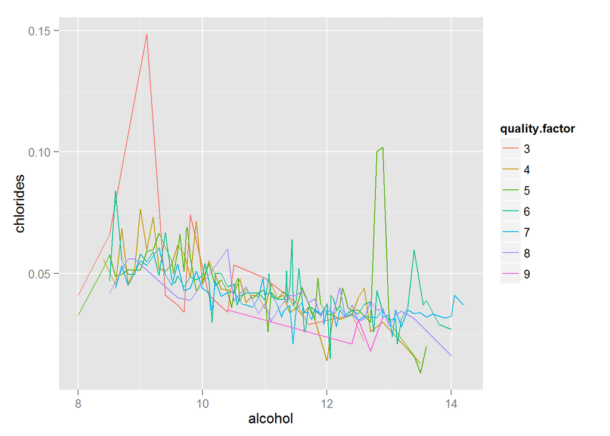

We could note a global tend that the chlorides value decrease when alcohol content increase. However, the lines of different qualities mixed together and there was too much variance on these lines. To have a better view, I was going to smooth the mean lines.

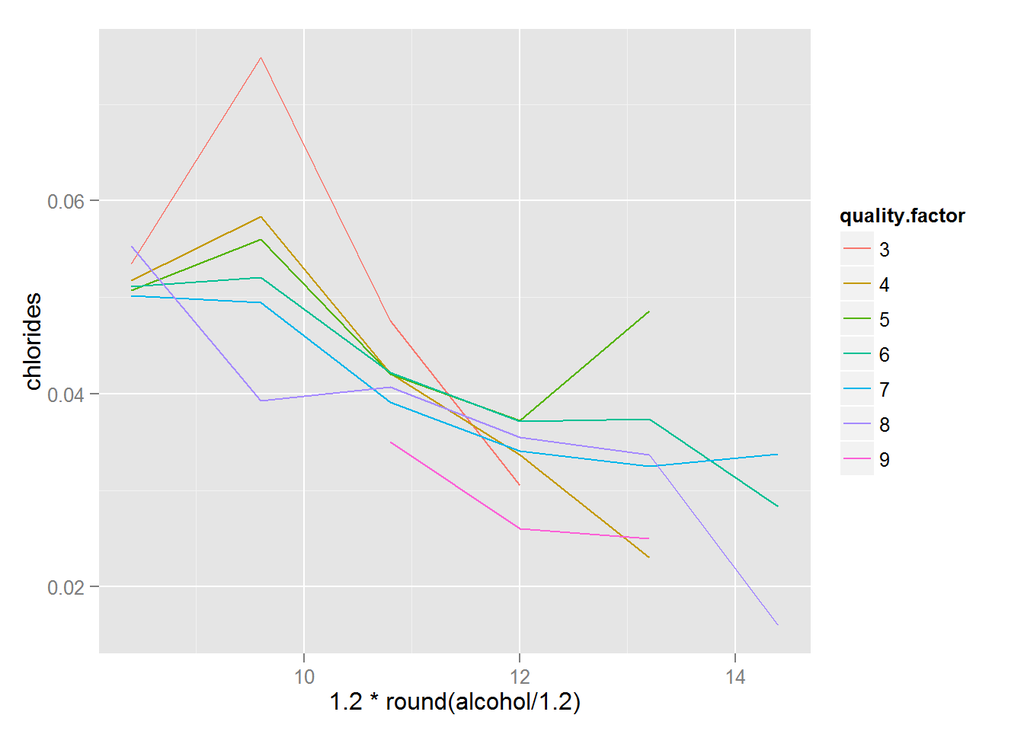

Now the plot was much more clear, and we noted that on holding alcohol level constant, higher quality wines generally have lower chlorides content.

Based on the analyse of bivariate and multivriate, I will try to build a model to predict the quality of white wine.

```
##
## Calls:
## m1: lm(formula = quality ~ alcohol + volatile.acidity + residual.sugar +
##     chlorides + total.sulfur.dioxide, data = wine)
## m2: lm(formula = quality ~ alcohol + volatile.acidity + residual.sugar +
##     chlorides + total.sulfur.dioxide + density, data = wine)
## m3: lm(formula = quality ~ alcohol + volatile.acidity + residual.sugar +
##     chlorides + total.sulfur.dioxide + density + pH, data = wine)
## m4: lm(formula = quality ~ alcohol + volatile.acidity + residual.sugar +
##     chlorides + total.sulfur.dioxide + density + pH + I(alcohol/acid.total),
##     data = wine)
## m5: lm(formula = quality ~ alcohol + volatile.acidity + residual.sugar +
##     chlorides + total.sulfur.dioxide + density + pH + I(alcohol/acid.total) +
##     I(total.sulfur.dioxide/pH), data = wine)
##
## =======================================================================================
##                                 m1          m2          m3          m4          m5
## ---------------------------------------------------------------------------------------
## (Intercept)                   2.334***   81.344***   103.491***  137.795***  135.458***
##                              (0.148)    (12.246)     (12.637)    (17.391)    (17.338)
## alcohol                       0.374***    0.284***     0.253***    0.253***    0.261***
##                              (0.011)     (0.018)      (0.018)     (0.018)     (0.018)
## volatile.acidity             -2.108***   -2.077***    -2.046***   -2.046***   -2.062***
##                              (0.110)     (0.110)      (0.110)     (0.109)     (0.109)
## residual.sugar                0.025***    0.053***     0.064***    0.077***    0.077***
##                              (0.003)     (0.005)      (0.005)     (0.007)     (0.007)
## chlorides                    -0.966      -0.769       -0.449      -0.286      -0.315
##                              (0.541)     (0.540)      (0.539)     (0.542)     (0.540)
## total.sulfur.dioxide          0.001       0.001**      0.001**     0.001**    -0.031***
##                              (0.000)     (0.000)      (0.000)     (0.000)     (0.005)
## density                                 -78.777***  -102.449*** -137.303*** -139.248***
##                                         (12.209)     (12.664)    (17.542)    (17.487)
## pH                                                     0.511***    0.715***    2.055***
##                                                       (0.077)     (0.104)     (0.254)
## I(alcohol/acid.total)                                             -0.283**    -0.337***
##                                                                   (0.099)     (0.099)
## I(total.sulfur.dioxide/pH)                                                     0.100***
##                                                                               (0.017)
## ---------------------------------------------------------------------------------------
## R-squared                        0.260       0.266       0.272       0.274       0.279
## adj. R-squared                   0.259       0.265       0.271       0.272       0.277
## sigma                            0.762       0.759       0.756       0.755       0.753
## F                              342.876     295.042     261.476     230.159     209.667
## p                                0.000       0.000       0.000       0.000       0.000
## Log-likelihood               -5618.852   -5598.094   -5575.968   -5571.848   -5555.125
## Deviance                      2844.239    2820.233    2794.867    2790.169    2771.181
## AIC                          11251.704   11212.189   11169.936   11163.697   11132.250
## BIC                          11297.180   11264.161   11228.405   11228.662   11203.713
## N                             4898        4898        4898        4898        4898
## =======================================================================================
```

However, according to the summary above, these models were not so good, indeed rather poor to predict the quality. The R-Square values haven’t even exceeed 0.3, though they increased gradually when we introduced more and more variables. Thus we could deduce that even we include all variables, the model will not improve drastically, so not good enough to predict the wine quality.

# Multivariate Analysis

### Talk about some of the relationships you observed in this part of the investigation. Were there features that strengthened each other in terms of looking at your feature(s) of interest?

At the beginning of the multivriate plot section, I explored the relationship of alcohol/acid.total with quality. According to the plots, it seems that alcohol/acid.total increase when the quality of wine increase. While the mean of total.sulfur.dioxide/pH tends to be slightly decreased when the quality becomes better.

For the plots of chlorides against alcohol for different qualities of wine, better qualities wines seem to have higher alcohol content on holding chlorides level constant. Oppositely, when holding alcohol level constant, better qualities wines tend to have lower chorides content. We also noticed that there was more variance of chlorides value when the alcohol content was low.

Yes, residual.sugar and density, or alcohol and density strenghthened each other as they were strongly correlated according to the analyse of bivariate section.

### Were there any interesting or surprising interactions between features?

I didn’t notice any surprising interactions in this section. But some plots confirmed interesting relatoinships between density and residual.sugar, denstity and alcohol, for which I built a linear model in the bivariate section.

### OPTIONAL: Did you create any models with your dataset? Discuss the strengths and limitations of your model.

In Multvariate section, I tried to creat a model to predict the wine quality. However, the models I tried were not good at all for the prediction. I think it’s really hard or maybe impossible to find an appropriate model based on this dataset. One reasonable explanation is that the quality is graded on integer but not on float as other variables.

# Final Plots and Summary

### Plot One

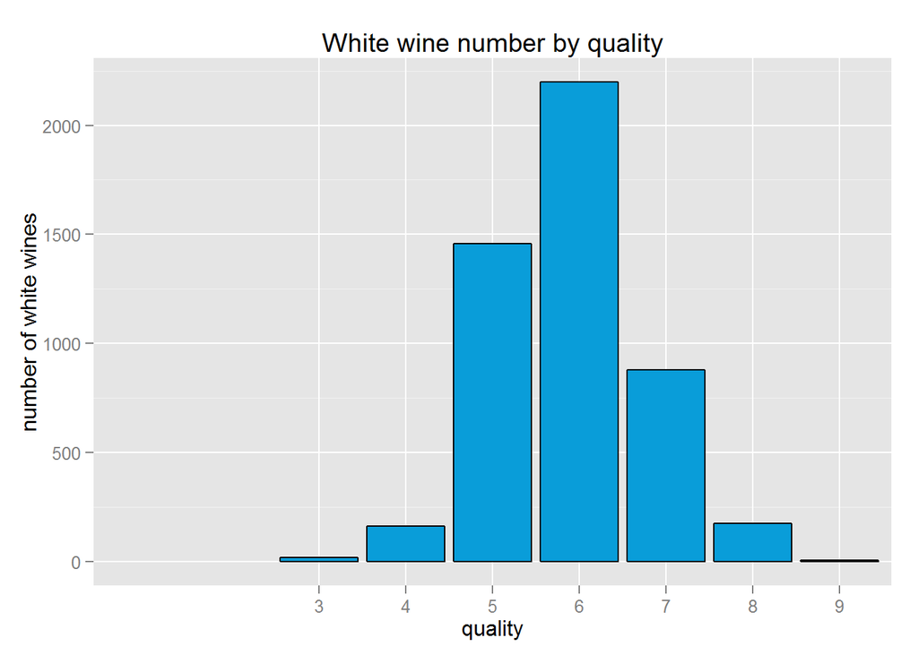

### Description One

The quality is a distrete. There is no extremly excellent wines (quality=10), nor extremely poor wines (quality=0, 1 or 2). Excellent wines (quality=8 or 9) and poor wines (quality=3 or 4) are also rare. Most wines are of quality 5, 6 and 7, among which the quality 6 has most number of wines, and is more than twice the number of wines of quality 7.

### Plot Two

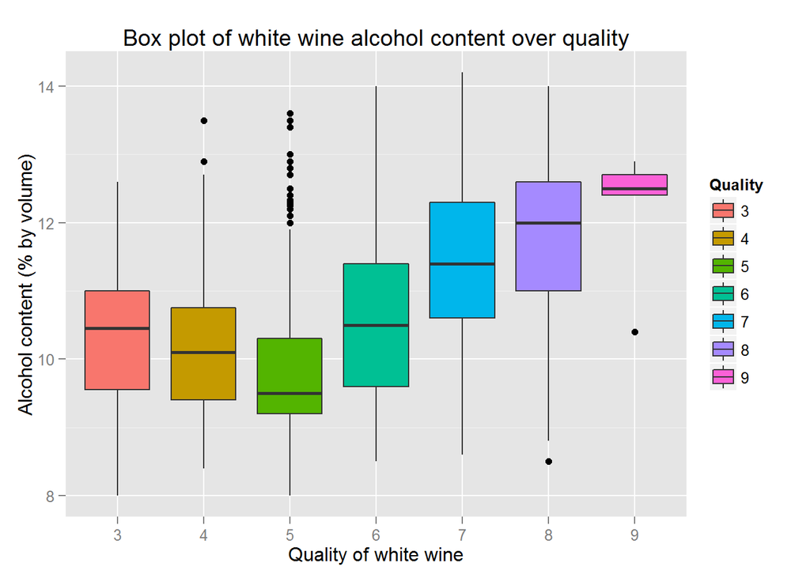

### Description Two

For good wines (quality >= 5), the mean of alcohol content increases when the quality of white wine becomes better. However, for bad quality wines, it seems to be opposite, the mean alcohol level decreases when the quality increase. There is no much difference on variance of alcohol content for quality 6, 7 and 8.

### Plot Three

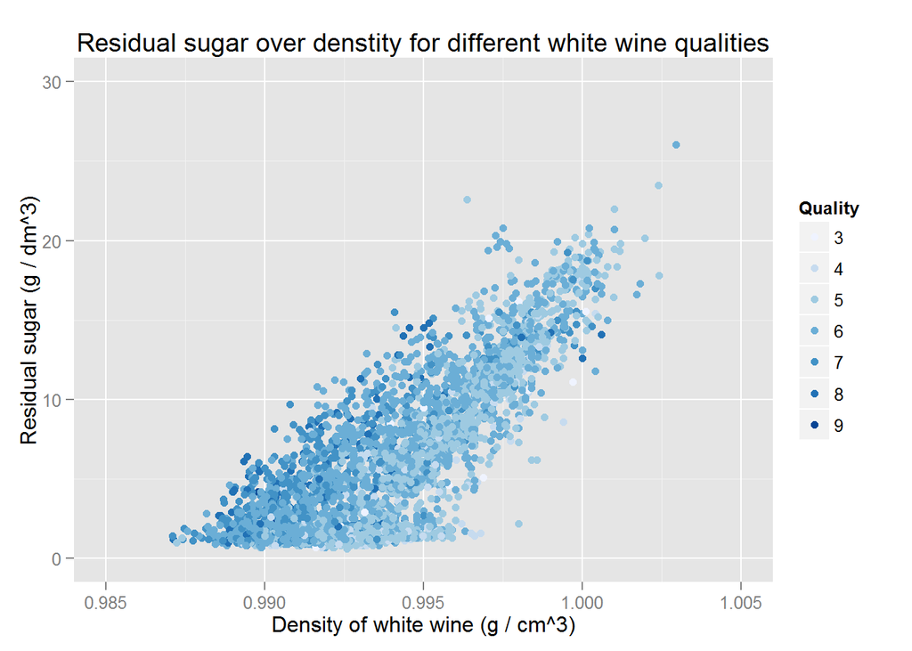

### Description Three

Holding residual sugar level constant, whites wines who have larger density tend to be of worse quality in general. The plot also indicates that a linear model could be constructed between residual sugar and density, and the coefficients of the model would vary following different qualities of wines.

# Reflection

What excited me most in exploring this dataset was that I succeed in builing a linear model of wine’s density by including residual.sugar and alcohol as input variables. Residual.sugar and alcohol both have a strong correlation with denstiy, so the model was not difficult to be found. However, I was struggling in creating a linear model to predict the white wine quality, and the model I built was rather poor for the prediction. I think the possible reasons for this hardness may be :

1. The number of different qualities of wines is not balanced in this dataset. There are too much normal wines comparing the number of excellent wines or poor ones, which makes the analyse less reliable if we want to look into the tends towards excellent wines or poor ones.
2. The quality itself is very subjective according to the evaluation system. Different wine experts could give totally different notes to the same wine. Determining a wine’s quality just by taking the median of all notes may be an approach too simple and light. In addition, the quality variable is graded on integer while all other input variables are of type float (number). This could introduce some bias as the aggregation levels of input & ouput variables are not the same. To investigate this dataset furthur and make the model better, I would perhaps include some rounding system in the quality predition model, or do some groupment of values on each input varible in order to match the quality’s aggregation level.
3. The dataset only consists of wines collected from a specific portugal region. So there may be some bias created by the specfic qualities of the product of this region. It will be insteresting to analyse on a dataset accross various wine making regions.